# MA331-Report: 2211744

TED Talks by Speaker JR and Speaker Hugh Evans

Karunaratne, Mahawattege Dona Dilshani Nimeshika

## Introduction

This report is going to analyse the ted_talks data set, specifically the TED talks of “JR” and “Hugh Evans”. Let’s first explore the complete data set. It has columns for talk_id, headline, text, speaker, and views. Following is a simple summary of the complete data set.

| Measure | Counts |
| --- | --- |
| Number of speakers involved | 849 |
| Number of TED talks | 992 |
| Total Views | 2065473321 |

Now, let’s take look at who have given the most number of the TED talks in this data set. Below are the top 5 speakers.

| Speaker | Number of TED talks |
| --- | --- |
| Bill Gates | 5 |
| Stewart Brand | 5 |
| Al Gore | 4 |
| Dan Dennett | 4 |
| Robert Full | 4 |

Next, we can check the most viewed topics of the speakers. Below is the hot 5 topics.

| Speaker | Topic | Views |
| --- | --- | --- |
| Ken Robinson | Do schools kill creativity? | 51614087 |
| Mary Roach | 10 things you didn’t know about orgasm | 23296221 |
| Jill Bolte Taylor | My stroke of insight | 22395388 |
| Tony Robbins | Why we do what we do | 22368699 |
| Tim Urban | Inside the mind of a master procrastinator | 19641453 |

As stated at the beginning, in this report I’m going to analyze TED talks by JR and Hugh Evans. Let’s have a look at how many TED talks have been conducted by each speaker.

| Speaker | Number of ted talks |
| --- | --- |
| Hugh Evans | 1 |
| JR | 2 |

## Methods

As the data set has few columns, the number of basic statistical calculations that can be done is limited. Let’s try to gain some insights out of view counts. To do this, I grouped the full data set into ‘JR and Hugh Evans’ and ‘All the other speakers’. Here’s a box plot of the summaries.

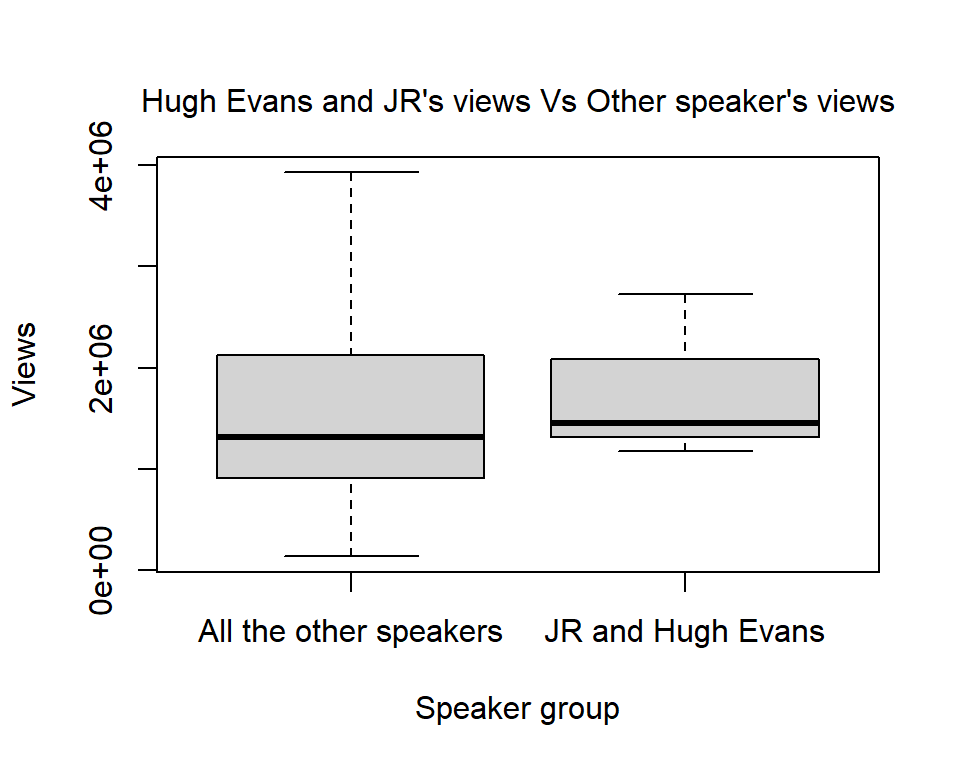

By looking at the boxplot, we can say the views of JR and Hugh Evan’s TED talks are higher than the rest of the speakers’ average views. Then, I calculated the minimum, average, and maximum view counts of JR, Hugh Evans, and the rest of the speakers.

[output not shown]

Now, let’s look at the top words from the two speakers. In order to achieve this output, tidying the data set, tokenizing and removing stop words should be taken place.

| Word | Hugh Evans | JR |
| --- | --- | --- |
| global | 39 | 2 |
| people | 8 | 30 |
| citizens | 27 | 0 |
| just | 4 | 27 |
| project | 0 | 26 |
| world | 13 | 25 |
| art | 0 | 23 |

Above table shows the top words of Hugh Evans and JR. “People” is the word mostly used by JR, while Hugh Evans has used “global” mostly in their TED talks. Let’s visualize the top words of each speaker in a single bar chart. Beside this, the common top words of both speakers are plotted to visualize the frequency and give a more comparative view.

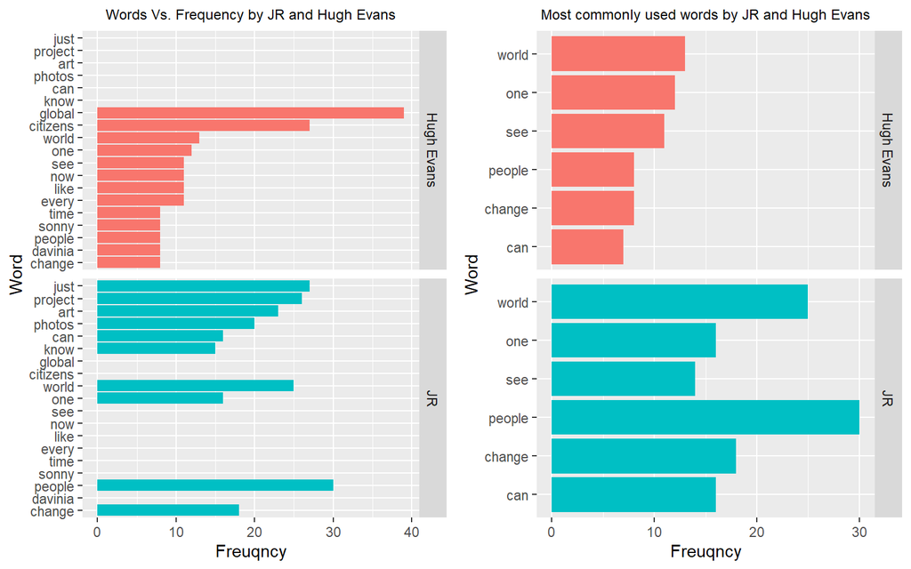

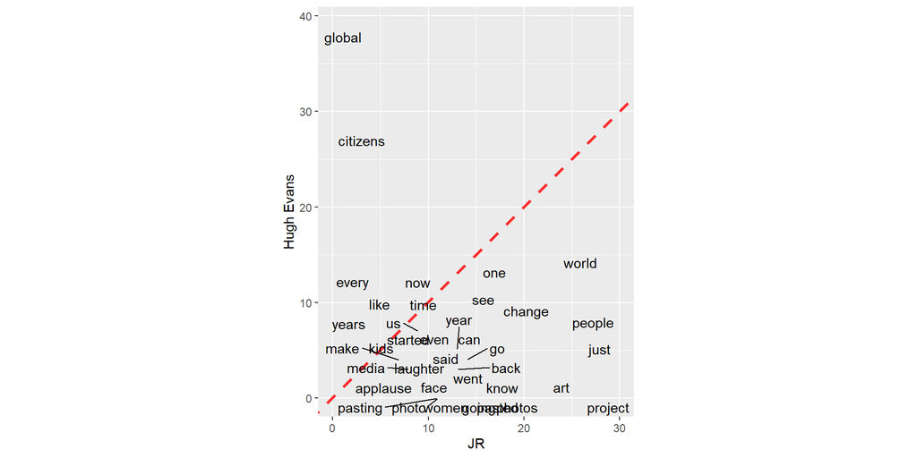

By this plot, we can understand how commonly are words used by both speakers. Most of the common words are in the frequency range of zero to ten. There are a couple of words that are placed in areas that are away from the speaker. Eg : Global, citizen, world, people, just and project.

Next, we can start analyzing the sentiments. As a start, I’m going to use “bing” lexicons to get positive and negative sentiments.

Sentiments of Hugh Evans and JR based on “bing” lexicon

| Sentiment | Hugh Evans | JR |
| --- | --- | --- |
| negative | 60 | 56 |
| positive | 80 | 72 |

Above table shows that Hugh Evans has both more positive and negative sentiments than JR. “Bing” lexicon only gives positive and negative sentiments. I’d like to expand the sentiments into more categories in order to analyze further. Therefore, I’m going to use “nrc” lexicon to analyze both speakers sentiments.

Sentiments of Hugh Evans and JR based on “nrc” lexicon

| Sentiment | Hugh Evans | JR |
| --- | --- | --- |
| anger | 29 | 28 |
| anticipation | 69 | 85 |
| disgust | 24 | 15 |
| fear | 43 | 57 |
| joy | 47 | 81 |
| negative | 72 | 64 |
| positive | 116 | 163 |
| sadness | 29 | 49 |
| surprise | 29 | 57 |
| trust | 62 | 93 |

In both speakers’ TED talks, positive sentiments take the lead, and disgust sentiments are the lowest. Anticipation and trust sentiments are more common in the two speakers’ vocabulary. However, the tables show that Hugh Evans has more negative sentiments than JR while JR has more fear and sadness sentiments than Hugh Evans.

## Results

In this section, I am going to calculate the odds ratio and confidence intervals. This can be used to measure the strength of a word’s association. First, let’s consider OR value. When the OR value is greater than 1, it means one speaker has more particular sentiments than the other speaker. When it’s equal to 1, it means both speakers have the same amount of sentiment. Lastly, when it’s less than 1, the previous speaker has fewer sentiments than the later speaker. By looking at the Odds Ratio(OR) values below table, I can say that surprise, joy, sadness, trust, and positive sentiments are higher in JR’s TED talks, while fear, anticipation, anger, and negative and disgust sentiments are common in Hugh Evan’s TED talks.

[output not shown]

There can be scenarios where the sentiment is assigned randomly. Therefore, it’s general to calculate confidence interval(CI) which gives a range with upper and lower level where 95% of true values falls under that range. In this, the upper bound relates to positive sentiments, while the lower bound relates to negative sentiments.

To calculate CI for sentiment analysis, we use the log value of the OR. After obtaining the log(OR), the standard error(SE) for the log(OR) is calculated. After that, to compute the CI, a function is written using the log(OR) value and adding the product of the standard normal distribution value and SE. The function finds the upper and lower limits of the confidence interval. The above table displays the final results.

Let’s plot the association between the log odds ratio and the sentiments to present the data in a more attention-grabbing way.

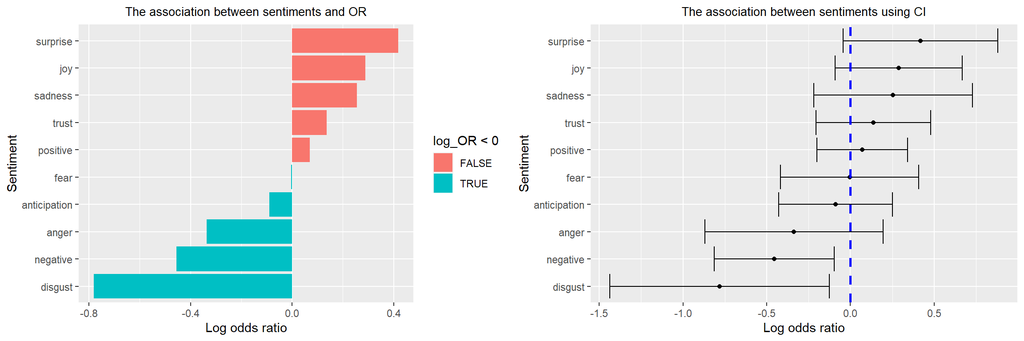

As depicted in the above table with CI.Upper and CI.Lower levels, we can say that JR and Hugh Evans share the same amount of words related to some sentiments such as fear, anticipation, and positive. According to the sentiments given to each word, we can assess which particular words are accountable for these tendencies. Below are the six words responsible for negative and positive sentiments, respectively.

| Word | JR | Hugh Evans | OR | Sentiment |
| --- | --- | --- | --- | --- |
| conflict | 4 | 1 | 2.7518023 | negative |
| government | 1 | 5 | 0.1369666 | negative |
| poverty | 0 | 7 | 0.0000000 | negative |
| art | 23 | 0 | Inf | positive |
| applause | 9 | 2 | 3.1014455 | positive |
| laughter | 8 | 4 | 1.3756450 | positive |

For visual representations, let’s plot and see which words are accountable for the sentiments and their frequencies.

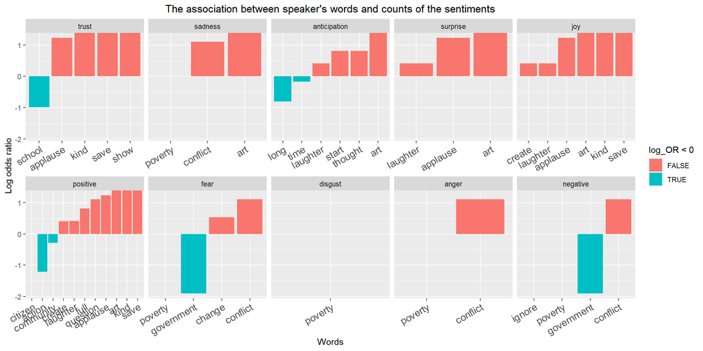

All 3 speeches were related to initiatives to change the world and help end global poverty. Overall, the 3 speeches had positive sentiments, such as how they achieved specific goals in their initiatives, which also contributed to anticipation sentiments. The same negative and sad sentiments can be highlighted too as anger towards the government and the sad side of the world were also addressed in the TED talks. To conclude, I can say that the sentiment analysis carried out above is suitable to make a fair judgement about the 3 TED talks.